# SI 618: Data Manipulation and Analysis

## 07 - Natural Language Processing

### Dr. Chris Teplovs, School of Information, University of Michigan

This work is licensed under a [Creative Commons Attribution-NonCommercial-ShareAlike 4.0 International License](http://creativecommons.org/licenses/by-nc-sa/4.0/).

# Outline for today

- regular expressions redux
- `nltk`
  - Cleaning the data
  - Extracting linguistic features
- `Word2Vec`
  - Vector representation of words
  - Word similarities
  - Vector algebra for semantics

# Why learn NLP?

- Natural language = human language
- We use language to learn about the world
- How machines understand human langauge?
- How can we quantify the meaning of language?

## Applications?

- Probabily any service that uses text as information
- Search engine, SNS
  - What's the document about?
  - How do you determine the similarity?
- Virtual assistants: Alexa, Google Assistant, Cortana, etc.
  - Understand the semantic information from your speech from parsed text
- Biology, genetics
  - Genetic information / DNA sequence as text
  - Draw networks of proteins/molecules from vast amount of scientific papers

```python
import pandas as pd
import numpy as np
import re
import seaborn as sns
import matplotlib.pyplot as plt
%matplotlib inline
```

```python
UNIQNAME = 'drewpap'
```

# Regular Expressions

**Note:** we have included a cheat sheet for regular expressions.

Regular expressions are simply a way to find sequences of characters within strings. Let's use, as our text, "Bereft", a poem by Robert Frost:

```python
bereft = """Where had I heard this wind before
Change like this to a deeper roar?
What would it take my standing there for,
Holding open a restive door,
Looking down hill to a frothy shore?
Summer was past and the day was past.
Sombre clouds in the west were massed.
Out on the porch's sagging floor,
Leaves got up in a coil and hissed,
Blindly striking at my knee and missed.
Something sinister in the tone
Told me my secret my be known:
Word I was in the house alone
Somehow must have gotten abroad,
Word I was in my life alone,
Word I had no one left but God."""
```

To make our lives simpler (we'll discuss why this is the case in class), we're going to strip the newlines from the passage:

```python
bereft = bereft.replace('\n',' ')
```

```python
bereft
```

```
"Where had I heard this wind before Change like this to a deeper roar? What would it take my standing there for, Holding open a restive door, Looking down hill to a frothy shore? Summer was past and the day was past. Sombre clouds in the west were massed. Out on the porch's sagging floor, Leaves got…
```

Let's say we wanted to find all the occurrences of the word "alone". We could use plain old string functions:

```python
bereft.find('alone')
```

```
451
```

```python
if 'alone' in bereft:
    print('Yup, found it')
```

```
Yup, found it
```

```python
bereft.count('alone')
```

```
2
```

Ok, now try it yourself:

### Q1: How many times does the word `was` appear in the poem?</a>

```python
# insert your code here
bereft.count('was')
```

```
4
```

So far, so good. Now let's make things a bit more interesting. How many words are there that contain the letters `one` ?

```python
bereft.count('one')
```

```
4
```

```python
import re
```

```python
re.findall('one',bereft)
```

```
['one', 'one', 'one', 'one']
```

But what if we wanted to know the words that contained `one` instead of just the count? Enter regular expressions!

```python
re.findall('[a-z]+one',bereft)
```

```
['tone', 'alone', 'alone']
```

### Some useful online resources:

- www.debuggex.com
- www.regexr.com

```python
re.search('[a-z]*one',bereft)
```

```
<re.Match object; span=(391, 395), match='tone'>
```

```python
match = re.search('[a-z]*one', bereft)
```

```python
if match:
    print("Found it!")
```

```
Found it!
```

```python
if match:
    print("Found it!")
    print(match.group(0))
```

```
Found it!
tone
```

### Match Groups

In the above example, we used `match.group(0)` to extract the entire match.

Match groups also allow you to extract only certain parts of the match. In the previous example, say we wanted to know which letters preceded the letters 'one'. We could use match groups, specified by paretheses, to extract only certain parts.

```python
match = re.search('([a-z]*)one', bereft)
```

```python
if match:
    print("Found it!")
    print(match.group(0)) #Entire sequence of letters found
    print(match.group(1)) #First set of parenthesis
```

```
Found it!
tone
t
```

[output not shown]

How would we extract all the letters that precede *one*? Use `re.finditer()`

```python
matches = re.finditer('([a-z]*)one', bereft)
```

```python
for match in matches:
    print(match.group(0),match.group(1))
```

```
tone t
alone al
alone al
one
```

```python
re.split(',',bereft)
```

```
['Where had I heard this wind before Change like this to a deeper roar? What would it take my standing there for',
 ' Holding open a restive door',
 " Looking down hill to a frothy shore? Summer was past and the day was past. Sombre clouds in the west were massed. Out on the porch's sagging floor",
 ' Leaves got up in a coil and hissed',
 ' Blindly striking at my knee and missed. Something sinister in the tone Told me my secret my be known: Word I was in the house alone Somehow must have gotten abroad',
 ' Word I was in my life alone',
 ' Word I had no one left but God.']
```

### Q2: Experiment with various regular expressions such as \W, \w, \s, \S to see how the poem can be split.

```python
# Insert your code here
re.split('\W',bereft)
```

```
['Where',
 'had',
 'I',
 'heard',
 'this',
 'wind',
 'before',
 'Change',
 'like',
 'this',
 'to',
 'a',
 'deeper',
 'roar',
 '',
 'What',
 'would',
 'it',
 'take',
 'my',
 'standing',
 'there',
 'for',
 '',
 'Holding',
 'open',
 'a',
 'restive',
 'door',
 '',
 'Looking',
 'down',
 'hill',
 'to',
 'a',
 'frothy',
 'shore',
 '',
 'Summer',
 'was',
```

[output cut: 68 more lines]

```
 'was',
 'in',
 'my',
 'life',
 'alone',
 '',
 'Word',
 'I',
 'had',
 'no',
 'one',
 'left',
 'but',
 'God',
 '']
```

```python
re.split('\w',bereft)
```

```
['',
 '',
 '',
 '',
 '',
 ' ',
 '',
 '',
 ' ',
 ' ',
 '',
 '',
 '',
 '',
 ' ',
 '',
 '',
 '',
 ' ',
 '',
 '',
 '',
 ' ',
 '',
 '',
 '',
 '',
 '',
 ' ',
 '',
 '',
 '',
 '',
 '',
 ' ',
 '',
 '',
 '',
 ' ',
 '',
```

[output cut: 374 more lines]

```
 '',
 ' ',
 '',
 '',
 ' ',
 '',
 '',
 '',
 ' ',
 '',
 '',
 ' ',
 '',
 '',
 '.']
```

```python
re.split('\S',bereft)
```

```
['',
 '',
 '',
 '',
 '',
 ' ',
 '',
 '',
 ' ',
 ' ',
 '',
 '',
 '',
 '',
 ' ',
 '',
 '',
 '',
 ' ',
 '',
 '',
 '',
 ' ',
 '',
 '',
 '',
 '',
 '',
 ' ',
 '',
 '',
 '',
 '',
 '',
 ' ',
 '',
 '',
 '',
 ' ',
 '',
```

[output cut: 388 more lines]

```
 ' ',
 '',
 '',
 ' ',
 '',
 '',
 '',
 ' ',
 '',
 '',
 ' ',
 '',
 '',
 '',
 '']
```

```python
re.split('\s',bereft)
```

```
['Where',
 'had',
 'I',
 'heard',
 'this',
 'wind',
 'before',
 'Change',
 'like',
 'this',
 'to',
 'a',
 'deeper',
 'roar?',
 'What',
 'would',
 'it',
 'take',
 'my',
 'standing',
 'there',
 'for,',
 'Holding',
 'open',
 'a',
 'restive',
 'door,',
 'Looking',
 'down',
 'hill',
 'to',
 'a',
 'frothy',
 'shore?',
 'Summer',
 'was',
 'past',
 'and',
 'the',
 'day',
```

[output cut: 54 more lines]

```
 'Word',
 'I',
 'was',
 'in',
 'my',
 'life',
 'alone,',
 'Word',
 'I',
 'had',
 'no',
 'one',
 'left',
 'but',
 'God.']
```

We are going to load some data for use later on:

```python
# link='https://raw.githubusercontent.com/vineetdhanawat/twitter-sentiment-analysis/master/datasets/Sentiment%20Analysis%20Dataset.csv'
# sentiment_df = pd.read_csv(link,encoding="ISO-8859-1")
```

[output not shown]

## NOTE: Install the nltk and gensim libraries now. Windows users may need to implement some work-arounds to get spaCy to work properly.

```python
!conda install -y nltk gensim
```

[output not shown]

[output cut: 28 more lines]

[output not shown]

## Natural Language Processing

- often implemented as a pipeline with one or more of the following steps:
  - normalization
  - tokenization ** string of words and breaking it up
  - stemming
  - lemmatization
  - part-of-speech tagging
  - named entity recognition

# nltk

The Natural Language ToolKit (nltk) is the most common NLP package for python.

https://www.nltk.org/

```python
import nltk
```

```python
# You should only ever need to do this once
nltk.download("book")
```

```
True
```

```python
sentence = """This is a very simple sentence, which is used for teaching natural language processing, that Chris wrote on Saturday."""
```

### Tokenization

```python
tokens = nltk.word_tokenize(sentence)
```

```python
tokens
```

```
['This',
 'is',
 'a',
 'very',
 'simple',
 'sentence',
 ',',
 'which',
 'is',
 'used',
 'for',
 'teaching',
 'natural',
 'language',
 'processing',
 ',',
 'that',
 'Chris',
 'wrote',
 'on',
 'Saturday',
 '.']
```

### Removing stopwords

Words that has small contribution to the meaning of phrases but appear frequently. It is advised to remove them in most tasks.

```python
# load list of stopwords from nltk
from nltk.corpus import stopwords
print(stopwords.words('english'))
```

```
['i', 'me', 'my', 'myself', 'we', 'our', 'ours', 'ourselves', 'you', "you're", "you've", "you'll", "you'd", 'your', 'yours', 'yourself', 'yourselves', 'he', 'him', 'his', 'himself', 'she', "she's", 'her', 'hers', 'herself', 'it', "it's", 'its', 'itself', 'they', 'them', 'their', 'theirs', 'themselve…
```

```python
S = set(stopwords.words('english'))
tokens_stop_removed = []
for token in tokens:
    if not token.lower() in S:
        tokens_stop_removed.append(token)
sent_stop_removed = ' '.join(tokens_stop_removed)
print("Stopwords removed: ",sent_stop_removed)
```

```
Stopwords removed:  simple sentence , used teaching natural language processing , Chris wrote Saturday .
```

```python
from collections import Counter
Counter(tokens_stop_removed).most_common(10)
```

```
[(',', 2),
 ('simple', 1),
 ('sentence', 1),
 ('used', 1),
 ('teaching', 1),
 ('natural', 1),
 ('language', 1),
 ('processing', 1),
 ('Chris', 1),
 ('wrote', 1)]
```

## Part-of-speech tagging

Sometimes it's useful to know what part of speech (e.g. noun, verb, adjective, adverb, etc.) a word is. nltk supports part-of-speech tagging. Here's a list of what the POS codes mean (from https://www.guru99.com/pos-tagging-chunking-nltk.html)

```
Abbreviation    Meaning
CC  coordinating conjunction
CD  cardinal digit
DT  determiner
EX  existential there
FW  foreign word
IN  preposition/subordinating conjunction
JJ  adjective (large)
JJR adjective, comparative (larger)
JJS adjective, superlative (largest)
LS  list market
MD  modal (could, will)
NN  noun, singular (cat, tree)
NNS noun plural (desks)
NNP proper noun, singular (sarah)
NNPS    proper noun, plural (indians or americans)
PDT predeterminer (all, both, half)
POS possessive ending (parent\ 's)
PRP personal pronoun (hers, herself, him,himself)
PRP$    possessive pronoun (her, his, mine, my, our )
RB  adverb (occasionally, swiftly)
RBR adverb, comparative (greater)
RBS adverb, superlative (biggest)
RP  particle (about)
TO  infinite marker (to)
UH  interjection (goodbye)
VB  verb (ask)
VBG verb gerund (judging)
VBD verb past tense (pleaded)
VBN verb past participle (reunified)
VBP verb, present tense not 3rd person singular(wrap)
VBZ verb, present tense with 3rd person singular (bases)
WDT wh-determiner (that, what)
WP  wh- pronoun (who)
WRB wh- adverb (how)
```

```python
tagged = nltk.pos_tag(tokens)
```

```python
tagged
```

```
[('This', 'DT'),
 ('is', 'VBZ'),
 ('a', 'DT'),
 ('very', 'RB'),
 ('simple', 'JJ'),
 ('sentence', 'NN'),
 (',', ','),
 ('which', 'WDT'),
 ('is', 'VBZ'),
 ('used', 'VBN'),
 ('for', 'IN'),
 ('teaching', 'VBG'),
 ('natural', 'JJ'),
 ('language', 'NN'),
 ('processing', 'NN'),
 (',', ','),
 ('that', 'IN'),
 ('Chris', 'NNP'),
 ('wrote', 'VBD'),
 ('on', 'IN'),
 ('Saturday', 'NNP'),
 ('.', '.')]
```

## Stemming

Remove suffix of word to generate a "base" word.

```python
from nltk.stem import PorterStemmer
e_words= ["wait", "waiting", "waited", "waits"]
ps =PorterStemmer()
for w in e_words:
    rootWord=ps.stem(w)
    print(rootWord)
```

```
wait
wait
wait
wait
```

```python
from nltk.stem import PorterStemmer
e_words= ["run", "running", "ran", "runs"]
ps =PorterStemmer()
for w in e_words:
    rootWord=ps.stem(w)
    print(rootWord)
```

```
run
run
ran
run
```

## Lemmatization

Lemmatization is the process of obtaining the root or base form of a word. It is a dictionary-based technique that does better with the more "hints" you give it:

```python
import nltk
from nltk.stem import 	WordNetLemmatizer
wordnet_lemmatizer = WordNetLemmatizer()
text = "studies studying cries cry"
tokenization = nltk.word_tokenize(text)
for w in tokenization:
    print("Lemma for {} is {}".format(w, wordnet_lemmatizer.lemmatize(w)))
```

```
Lemma for studies is study
Lemma for studying is studying
Lemma for cries is cry
Lemma for cry is cry
```

```python
from nltk.corpus import wordnet as wn
from nltk.stem.wordnet import WordNetLemmatizer
from nltk import word_tokenize, pos_tag
from collections import defaultdict
tag_map = defaultdict(lambda : wn.NOUN) # Easier to find the lemma of a word if you also include the part of speech, defaults to noun
tag_map['J'] = wn.ADJ
tag_map['V'] = wn.VERB
tag_map['R'] = wn.ADV

text = "This is one of a series of notebooks that is designed to help you learn about natural language processing."
tokens = word_tokenize(text)
lemma_function = WordNetLemmatizer()
for token, tag in pos_tag(tokens):
    lemma = lemma_function.lemmatize(token, tag_map[tag[0]]) #Token and the word net part of speech
    print("{} ({}) => {}".format( token, tag, lemma))
```

```
This (DT) => This
is (VBZ) => be
one (CD) => one
of (IN) => of
a (DT) => a
series (NN) => series
of (IN) => of
notebooks (NNS) => notebook
that (WDT) => that
is (VBZ) => be
designed (VBN) => design
to (TO) => to
help (VB) => help
you (PRP) => you
learn (VB) => learn
about (IN) => about
natural (JJ) => natural
language (NN) => language
processing (NN) => processing
. (.) => .
```

## Named Entity Recognition

```python
entities = nltk.chunk.ne_chunk(tagged)
```

```python
print(entities)
```

```
(S
  This/DT
  is/VBZ
  a/DT
  very/RB
  simple/JJ
  sentence/NN
  ,/,
  which/WDT
  is/VBZ
  used/VBN
  for/IN
  teaching/VBG
  natural/JJ
  language/NN
  processing/NN
  ,/,
  that/IN
  (PERSON Chris/NNP)
  wrote/VBD
  on/IN
  Saturday/NNP
  ./.)
```

```python
entities.pretty_print()
```

```
                                                                                  S
    ______________________________________________________________________________|_______________________________________________________________________________________________________
   |      |     |      |        |          |       |      |       |       |       |         |           |           |            |        |     |        |       |        |        |    PERSON
   |      |     |      |        |          |       |      |       |       |       |         |           |           |            |        |     |        |       |        |        |      |
This/DT is/VBZ a/DT very/RB simple/JJ sentence/NN ,/, which/WDT is/VBZ used/VBN for/IN teaching/VBG natural/JJ language/NN processing/NN ,/, that/IN wrote/VBD on/IN Saturday/NNP ./. Chris/NNP
```

```python
type(entities)
```

```
nltk.tree.Tree
```

```python
# df.shape
entities
```

[output not shown]

[output not shown]

```
Tree('S', [('This', 'DT'), ('is', 'VBZ'), ('a', 'DT'), ('very', 'RB'), ('simple', 'JJ'), ('sentence', 'NN'), (',', ','), ('which', 'WDT'), ('is', 'VBZ'), ('used', 'VBN'), ('for', 'IN'), ('teaching', 'VBG'), ('natural', 'JJ'), ('language', 'NN'), ('processing', 'NN'), (',', ','), ('that', 'IN'), Tree…
```

### Q4: Show the top 10 most common words, excluding stopwords, from the following text (from Robert Frost's "The Road Not Taken"). Store the word tokens in a list called `words`.

```python
two_roads = """Two roads diverged in a yellow wood,
And sorry I could not travel both
And be one traveller, long I stood
And looked down one as far as I could
To where it bent in the undergrowth;

Then took the other, as just as fair,
And having perhaps the better claim,
Because it was grassy and wanted wear;
Though as for that the passing there
Had worn them really about the same,

And both that morning equally lay
In leaves no step had trodden black.
Oh, I kept the first for another day!
Yet knowing how way leads on to way,
I doubted if I should ever come back.

I shall be telling this with a sigh
Somewhere ages and ages hence:
Two roads diverged in a wood, and I—-
I took the one less travelled by,
And that has made all the difference."""
```

```python
# insert your code here
words = nltk.word_tokenize(two_roads)
non_stop_words = []
for word in words:
    word = word.lower()
    if not word in S:
        non_stop_words.append(word)
words = non_stop_words
words
```

```
['two',
 'roads',
 'diverged',
 'yellow',
 'wood',
 ',',
 'sorry',
 'could',
 'travel',
 'one',
 'traveller',
 ',',
 'long',
 'stood',
 'looked',
 'one',
 'far',
 'could',
 'bent',
 'undergrowth',
 ';',
 'took',
 ',',
 'fair',
 ',',
 'perhaps',
 'better',
 'claim',
 ',',
 'grassy',
 'wanted',
 'wear',
 ';',
 'though',
 'passing',
 'worn',
 'really',
 ',',
 'morning',
 'equally',
```

[output cut: 31 more lines]

```
 ':',
 'two',
 'roads',
 'diverged',
 'wood',
 ',',
 'i—-',
 'took',
 'one',
 'less',
 'travelled',
 ',',
 'made',
 'difference',
 '.']
```

It's also possible to plot the frequency of words:

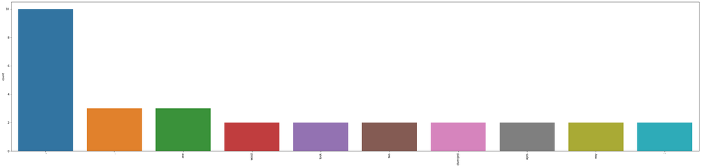

```python
plt.figure(figsize=(45,10))
sns.countplot(words, order=pd.Series(words).value_counts().index[:10])
plt.xticks(rotation=90)
plt.show()
```

(double click the plot to enlarge)

### Q5. Based on the word frequency results, what was the paragraph about?

Based on the word frequency results, the paragraph was about change, movement, time, and nature.

# Word embedding

- So far, we seen how we can extract some interesting syntactic characteristics from text from using `nltk`
- It extracted the characteristics, but did not indicate what it means
- Can machines understand semantic relationship between words?
- Distributional semantics
  - Representing semantic information of words in a geometric semantic space
    - Different relationship between words: explained by geometric relationship between words
    - e.g., Related words are located closer to each other;
  - And it's often called as *word embedding*

#### Word2Vec

- Developed by [Mikolov et al., 2013](https://papers.nips.cc/paper/5021-distributed-representations-of-words-and-phrases-and-their-compositionality.pdf)
- Represent the meaning of the words as a vector
  - Vector: numeric array
  - Output of a neural network model that predicts the next word
- Surprisingly, many different semantic informations can be represented from word vectors of `Word2Vec`
- (More explanation in here: https://www.tensorflow.org/tutorials/representation/word2vec)

[figure not shown]

### Let's try with some example: words in a semantic space

$\rightarrow$ https://projector.tensorflow.org

### Q6. Record any interesting findings from TensorFlow Projector page

Happy occurs in the projector but sad does not.

## OK. Let's try some more details on our local machines!

- We have included the [pretrained model](https://drive.google.com/open?id=10GXpuviDJVa-k8ZmiYX3BVABNDRaA6tg) as part of today's zip file, but there's the link for it if you ever need to download it again
- We are using [gensim](https://radimrehurek.com/gensim/) package this time

```python
import gensim
```

```python
# from https://github.com/eyaler/word2vec-slim
w2v_mod = gensim.models.KeyedVectors.load_word2vec_format("GoogleNews-vectors-negative300-SLIM.bin", binary=True)
```

## Calculating similarity between words

- Q: What's similarity between *school* and *student*?
- the word vector for *school* looks like this:

```python
w2v_mod['school']
```

```
array([ 3.70471478e-02,  1.14410305e-02,  1.49575379e-02,  8.87546614e-02,
        3.96226160e-02, -2.67452672e-02,  6.33961856e-02, -1.90188568e-02,
       -1.89445645e-03, -3.68490331e-02,  1.01037674e-01,  1.85235739e-02,
        2.69433800e-02, -4.00188453e-02, -4.29905392e-02,  4.31886539e-02,
       -8.12263638e-02,  5.72051527e-03,  5.54716662e-02, -3.56603563e-02,
        8.32074955e-02,  6.93395808e-02,  4.72994987e-03,  6.97358102e-02,
        1.96874887e-03, -1.41848966e-01,  9.22464067e-04,  7.48867467e-02,
        4.85377051e-02, -1.02028241e-02,  4.14056368e-02, -4.33867648e-02,
        1.62452739e-02,  3.04598873e-03, -6.61697686e-02, -6.06226064e-02,
        9.27169248e-02, -2.04056483e-02,  1.88207440e-02,  5.07169515e-02,
        5.29952534e-03,  5.19056283e-02,  4.47735563e-02, -2.05047056e-02,
        1.39669729e-02,  5.86414747e-02,  6.97358102e-02, -1.12924464e-02,
       -4.49716710e-02,  9.31131542e-02, -4.75471430e-02, -4.95282710e-02,
       -1.44251098e-03, -4.61603515e-02,  8.59810784e-02, -8.47924054e-02,
       -4.23962027e-02,  1.78301781e-02, -5.00235567e-03, -6.45848662e-02,
       -3.58584709e-02, -1.62452739e-02,  4.31886539e-02, -2.06037611e-02,
        3.14999819e-02,  5.94339259e-02, -7.01320320e-02,  8.39999467e-02,
        8.96461774e-03,  1.64433867e-02, -7.44905248e-02,  4.91320454e-02,
        3.52641307e-02,  1.49575379e-02, -4.51697856e-02,  1.44226328e-01,
        1.16490498e-01,  1.29392615e-03,  7.01320320e-02,  6.41886443e-02,
        2.02075355e-02, -6.77546784e-02, -6.10188320e-02,  8.43961760e-02,
        2.23867781e-02,  1.60471611e-02,  1.50565952e-02,  9.62829590e-02,
        6.73584491e-02, -1.14905592e-02, -7.37971254e-03, -7.68678784e-02,
       -5.54716634e-03, -6.22075088e-02, -7.23112794e-03,  3.82358246e-02,
        6.45848662e-02,  2.57547013e-02, -2.53584757e-02,  2.91226245e-02,
       -1.94150824e-02, -5.42334560e-03, -5.62641174e-02,  2.48631928e-02,
       -8.83584395e-02, -3.38773392e-02,  5.24999667e-03,  2.25848928e-02,
       -8.81603267e-03, -8.43961760e-02, -9.35093760e-02,  6.89433515e-02,
       -1.36698028e-02, -1.83254611e-02,  6.69622272e-02, -1.02152058e-04,
        2.71414928e-02, -2.02075355e-02, -5.74527942e-02, -6.57735467e-02,
       -4.55660112e-02, -6.16627000e-03,  1.00542391e-02, -8.81603267e-03,
       -2.41697971e-02, -1.83254611e-02, -3.34811136e-02, -5.50754406e-02,
        1.24439783e-03,  3.32829989e-02,  3.68490331e-02, -1.44226328e-01,
       -7.88490102e-02, -4.14056368e-02, -5.38867600e-02, -1.21344263e-02,
        1.10448049e-02, -4.23215215e-06, -1.12924464e-02,  2.85282843e-02,
       -1.44226328e-01, -1.44226328e-01,  5.26980832e-02,  1.85731018e-03,
       -1.05990507e-02,  8.71697590e-02, -3.92263904e-02, -3.86320539e-02,
       -9.01414547e-03,  1.92695938e-04,  1.64037645e-01, -7.21131638e-02,
       -3.66509221e-02,  6.06226064e-02, -8.36037248e-02, -5.23018539e-02,
        1.03811257e-01, -9.70754102e-02,  4.35848795e-02, -2.95188501e-02,
```

[output cut: 21 more lines]

```
       -1.10943332e-01, -4.71509136e-02, -6.65659979e-02, -2.67452672e-02,
        6.63678860e-03, -2.48879567e-03,  1.29764071e-02,  3.96226160e-02,
        5.62641174e-02,  5.78490235e-02, -3.54622416e-02, -1.08565971e-01,
        4.69528027e-02, -1.05495220e-02,  7.82546680e-03,  1.02226354e-01,
        1.86226312e-02,  5.66603430e-02, -1.00245222e-01, -3.74433734e-02,
        3.88301648e-02, -2.27830056e-02,  1.47594251e-02,  2.69433800e-02,
       -1.89197995e-02,  2.42688525e-02,  4.12075222e-02, -1.90188568e-02,
        3.68490331e-02,  8.47924054e-02, -3.16980928e-02, -1.02226354e-01,
        1.24415018e-01, -1.27584830e-01, -2.46650800e-02, -1.25999928e-01,
       -4.75471430e-02, -2.05047056e-02, -5.54716662e-02,  1.02226354e-01,
       -7.76603296e-02, -1.98113092e-04, -3.78395990e-02,  7.96414614e-02,
        6.14150576e-02,  1.21245213e-01, -4.37829942e-02, -9.70754120e-03,
       -5.98301515e-02, -2.71414928e-02,  4.25943136e-02, -2.32782885e-02,
       -4.29905392e-02, -5.07664774e-03,  3.68490331e-02,  4.87358198e-02],
      dtype=float32)
```

```python
len(w2v_mod['school'])
```

```
300
```

- and the word vector for *student* looks like this:

```python
w2v_mod['student']
```

```
array([ 0.01336551,  0.00730235,  0.08037006,  0.05629445,  0.06479172,
        0.01141821,  0.11400511, -0.01221483,  0.0559404 , -0.1359564 ,
        0.01849928, -0.04779717, -0.04337151, -0.05027555, -0.0073466 ,
        0.00477972, -0.02442967, -0.02389859, -0.00907261, -0.05098365,
        0.00783343,  0.06302146, -0.00064449, -0.03328099, -0.03540531,
       -0.17844278, -0.04956744, -0.002069  ,  0.06160524,  0.0366445 ,
        0.03416613, -0.03983098, -0.03080262,  0.01964995, -0.02372156,
       -0.00610742,  0.04071611,  0.0506296 , -0.03009452,  0.08072411,
       -0.08638897,  0.0426634 , -0.01672901,  0.03115668,  0.0619593 ,
       -0.02496075,  0.01451618, -0.03752963,  0.05771066,  0.0179682 ,
       -0.03947692, -0.05452418,  0.0054657 , -0.01964995,  0.0906376 ,
       -0.03452018, -0.04284043,  0.04036206,  0.07435116, -0.03629045,
        0.00610742, -0.03452018, -0.00111748, -0.00489036,  0.03363505,
       -0.0306256 ,  0.03080262, -0.02009252,  0.05735661,  0.03823774,
       -0.08391059,  0.02991749,  0.00533293, -0.07718358, -0.06479172,
        0.1586158 ,  0.05275392, -0.00624019,  0.03115668, -0.00068874,
        0.00982497, -0.04921339, -0.00654998,  0.07470521, -0.06160524,
        0.00986923, -0.04567285,  0.11117268, -0.01106416,  0.09028355,
       -0.04089314, -0.13454019, -0.0559404 , -0.06018903, -0.04301745,
        0.02673101,  0.06514578,  0.09559435, -0.0089841 , -0.073289  ,
        0.01301145, -0.03823774, -0.03274991, -0.13949694, -0.03469721,
       -0.02044657, -0.05239986, -0.06018903,  0.08674302, -0.08497275,
       -0.13808072, -0.05912687,  0.03611342,  0.00385033,  0.02991749,
       -0.04071611, -0.02903236, -0.01079862,  0.05417013,  0.06337551,
        0.02478372,  0.02708506, -0.01787968, -0.05098365,  0.0007247 ,
        0.02903236,  0.03770666,  0.00924964,  0.0279702 ,  0.09205382,
       -0.01885333, -0.10834026, -0.04744312, -0.03646747, -0.07541332,
       -0.04160124,  0.04779717,  0.01761414, -0.12533481,  0.01363105,
       -0.12958345, -0.07647548, -0.03310397,  0.02407561, -0.00893984,
        0.08568086, -0.0179682 ,  0.10904837,  0.05417013,  0.01646347,
        0.14870232,  0.01110842, -0.02071211,  0.01637496, -0.01318848,
       -0.07576737,  0.03876882, -0.07116468,  0.05558634,  0.01513577,
       -0.10550784,  0.00508951,  0.04372556,  0.08497275, -0.01708306,
        0.06727009,  0.06443767, -0.05841877,  0.04708907, -0.01141821,
       -0.01708306, -0.01088713,  0.02584588, -0.05771066,  0.0366445 ,
        0.01699455,  0.06372956, -0.00042044, -0.01203781,  0.05523229,
        0.04390259, -0.05239986,  0.05523229, -0.05983498,  0.0619593 ,
        0.02088914,  0.02195129,  0.00564272,  0.00955943, -0.04638096,
        0.05275392, -0.01283443, -0.02478372,  0.16074012, -0.15932392,
       -0.03292694,  0.06089714, -0.07505926,  0.01128544, -0.01363105,
       -0.0619593 ,  0.07718358,  0.03575937, -0.08072411, -0.0846187 ,
       -0.12958345, -0.01128544, -0.06125119, -0.03292694, -0.05487823,
        0.07789169, -0.04390259,  0.08886734, -0.1352483 , -0.09488624,
        0.04372556, -0.03505126,  0.00955943, -0.02832425, -0.01947292,
       -0.00482397, -0.10338352,  0.01726009, -0.01602091,  0.02885533,
        0.08638897,  0.00840876, -0.02159724,  0.06727009, -0.01504726,
        0.07647548,  0.04815122, -0.00242305,  0.06018903, -0.02903236,
       -0.04390259,  0.01079862, -0.02460669, -0.00241199,  0.11046458,
        0.14162125, -0.05523229, -0.02920938,  0.01469321, -0.04815122,
       -0.02637696, -0.11683753,  0.00588613, -0.06833225,  0.06408362,
       -0.01557834,  0.00435928,  0.01858779,  0.06018903, -0.03983098,
       -0.07789169,  0.01593239,  0.04407962, -0.01911887,  0.05912687,
        0.0226594 ,  0.00832025, -0.06762415, -0.11400511, -0.00433715,
        0.00840876, -0.0066385 ,  0.06939442, -0.07435116, -0.00272178,
        0.03593639, -0.03416613,  0.02257089,  0.08001601, -0.05700256,
       -0.0619593 ,  0.00615167, -0.10621594, -0.02655398, -0.06833225,
        0.00294307, -0.01787968, -0.04089314,  0.06974847, -0.04779717,
        0.03788368, -0.06549983,  0.04301745,  0.1246267 ,  0.08851328,
       -0.05487823, -0.04602691, -0.073289  , -0.03328099,  0.02097765,
        0.06231335,  0.01389659,  0.04160124,  0.03558234,  0.0313337 ],
      dtype=float32)
```

- the similarity between two word vectors is:

```python
w2v_mod.similarity('school', 'student')
```

```
0.60556275
```

### Methods for measuring similarity

- Euclidean distance
  - The most common use of distance
  - $ \sqrt{(x_1 - x_2)^2 + (y_1 - y_2)^2} $

```python
# (images from https://nickgrattan.wordpress.com/2014/06/10/euclidean-manhattan-and-cosine-distance-measures-in-c/)
np.sqrt(np.power((12-5), 2) + np.power((14-11), 2))
```

```
7.615773105863909
```

- Manhattan distance
  - Distance = the sum of differences in the grid
  - $|x_1 - x_2| + |y_1 - y_2|$

```python
np.abs(12-5) + np.abs(14-11)
```

```
10
```

- Cosine similarity
  - Often used to measure similarity between vectors
  - $cos(\theta) = \frac{\sum_{i=1}^{n} A_i B_i }{\sqrt{\sum_{i=1}^{n} A_i^2 } \sqrt{\sum_{i=1}^{n} B_i^2 }}$
  - https://en.wikipedia.org/wiki/Cosine_similarity

```python
a = np.array([12, 14])
b = np.array([5, 11])
a.dot(b) / (np.sqrt(np.sum(np.power(a, 2))) * np.sqrt(np.sum(np.power(b, 2))))
```

```
0.9605011450474118
```

```python
# (image from http://blog.christianperone.com/2013/09/machine-learning-cosine-similarity-for-vector-space-models-part-iii/)
```

[figure not shown]

- Cosine simiarity can go from -1 to 1
- But usually, we deal with 0 to 1 scores for comparing words in `Word2Vec`

### Q7. What's the cosine similarity between *school* and *tiger*?

- How would you interprete the results?

(type in your response here)

```python
# put your code here
w2v_mod.similarity('school', 'tiger')
```

```
0.08660267
```

There is effectively no relationship between school and tiger

### Q8. Try some other words. Any other interesting findings?

- Give 3 more examples.
- How would you interprete the results?

```python
# put your code here
w2v_mod.similarity('finger', 'hand')
```

```
0.5078384
```

```python
w2v_mod.similarity('eye', 'hand')
```

```
0.36058378
```

```python
w2v_mod.similarity('foot', 'hand')
```

```
0.22718483
```

It's interesting that as you get further away from the hand, the correlation decreases. It seems like the physical distance is being taken into account in the correlation.

## Analogy from word vectors

[figure not shown]

#### Can we approximate the relationship between words by doing - and + operations?

- $woman - man + king \approx ?$
- How this works?
  - $woman:man \approx x:king $
  - $\rightarrow woman - man \approx x - king $
  - $\rightarrow woman - man + king \approx x$
  - List top-10 words ($x$) that can solve the equation!

```python
w2v_mod.most_similar(positive=['woman', 'king'], negative=['man'])
```

```
[('queen', 0.7118192911148071),
 ('monarch', 0.6189674735069275),
 ('princess', 0.5902431607246399),
 ('prince', 0.5377322435379028),
 ('kings', 0.5236844420433044),
 ('queens', 0.5181134343147278),
 ('sultan', 0.5098593235015869),
 ('monarchy', 0.5087411999702454),
 ('throne', 0.5005807280540466),
 ('royal', 0.4938204884529114)]
```

- $Spain - Germany + Berlin \approx ?$
  - $\rightarrow Spain - Germany \approx x - Berlin $

```python
w2v_mod.most_similar(positive=['Spain', 'Berlin'], negative=['Germany'])
```

```
[('Madrid', 0.717348039150238),
 ('Barcelona', 0.5742595791816711),
 ('Malaga', 0.5547429323196411),
 ('Bilbao', 0.5404423475265503),
 ('Lisbon', 0.5366039276123047),
 ('Seville', 0.5312415361404419),
 ('Paris', 0.5251091718673706),
 ('Catalan', 0.5213973522186279),
 ('Rome', 0.5174577832221985),
 ('Bogota', 0.5146557688713074)]
```

### Q9. Any other interesting examples?

- Give 3 more examples.
- How would you interprete the results?

(type in your response here)

```python
# put your code here
w2v_mod.most_similar(positive=['cat', 'dog'], negative=['horse'])
```

```
[('cats', 0.6921097040176392),
 ('dogs', 0.6558438539505005),
 ('puppy', 0.6444454193115234),
 ('kitten', 0.6388148665428162),
 ('pooch', 0.6283186674118042),
 ('Doberman', 0.6271960735321045),
 ('beagle', 0.6223675012588501),
 ('pup', 0.6163509488105774),
 ('Rottweiler', 0.6161229610443115),
 ('pet', 0.6147453784942627)]
```

```python
w2v_mod.most_similar(positive=['red', 'roses'], negative=['violet'])
```

```
[('yellow', 0.47905832529067993),
 ('carnations', 0.425118088722229),
 ('flowers', 0.42478111386299133),
 ('bouquets', 0.40576308965682983),
 ('shirts', 0.38555586338043213),
 ('purple', 0.3822409212589264),
 ('pink', 0.37342867255210876),
 ('stickers', 0.36479347944259644),
 ('carnation', 0.3605183959007263),
 ('shamrocks', 0.3594288229942322)]
```

```python
w2v_mod.most_similar(positive=['fire', 'water'], negative=['up'])
```

```
[('Fire', 0.490995854139328),
 ('Water', 0.49090248346328735),
 ('blaze', 0.48949021100997925),
 ('groundwater', 0.4840303063392639),
 ('flames', 0.47613269090652466),
 ('flashovers', 0.46578675508499146),
 ('firefighters', 0.46539029479026794),
 ('aquifer', 0.4627683758735657),
 ('standpipes', 0.4405038356781006),
 ('firefighting', 0.440151572227478)]
```

The most accurate of the above three is the relationship between red to roses and violet to yellow. I was expecting blue, so for the model to predict another color was surprising. Additionally, the correlation is low so it had some measure of uncertainty.

## Constructing interpretable semantic scales

- So far, we saw that word vectors effectively carries (although not perfect) the semantic information.
- Can we design something more interpretable results from using the semantic space?
- Let's re-try with real datapoints in [here](https://projector.tensorflow.org): *politics* words in a *bad-good* PCA space

```python
from scipy import spatial

def cosine_similarity(x, y):
    return(1 - spatial.distance.cosine(x, y))
```

- Can we regenerate this results with our embedding model?

### Let's plot words in the 2D space

- Using Bad & Good axes
- Calculate cosine similarity between an evaluating word (violence, discussion, and issues) with each scale's end (bad, and good)

```python
pol_words_sim_2d = pd.DataFrame([[cosine_similarity(w2v_mod['violence'], w2v_mod['good']), cosine_similarity(w2v_mod['violence'], w2v_mod['bad'])],
                                 [cosine_similarity(w2v_mod['discussion'], w2v_mod['good']), cosine_similarity(w2v_mod['discussion'], w2v_mod['bad'])],
                                 [cosine_similarity(w2v_mod['issues'], w2v_mod['good']), cosine_similarity(w2v_mod['issues'], w2v_mod['bad'])]],
                                index=['violence', 'discussion', 'issues'], columns=['good', 'bad'])
```

```python
pol_words_sim_2d
```

[output not shown]

- If we plot this:

```python
sns.scatterplot(x='good', y='bad', data=pol_words_sim_2d, hue=pol_words_sim_2d.index)
```

[output not shown]

### Can we do this in an 1D scale?

(bad) --------------------?---- (good)

- First, let's create the vector for *bad-good* scale

```python
scale_bad_good = w2v_mod['good'] - w2v_mod['bad']
```

```python
cosine_similarity(w2v_mod['violence'], scale_bad_good)
```

[output not shown]

```python
cosine_similarity(w2v_mod['discussion'], w2v_mod['good'] - w2v_mod['bad'])
```

[output not shown]

```python
cosine_similarity(w2v_mod['issues'], w2v_mod['good'] - w2v_mod['bad'])
```

[output not shown]

In summary, as displayed in Embedding Projector, words *violence*, *discussion*, and *issues* are located in the *bad-good* scale as following:

```python
pol_words_sim = pd.DataFrame([cosine_similarity(w2v_mod['violence'], w2v_mod['good'] - w2v_mod['bad']),
                              cosine_similarity(w2v_mod['discussion'], w2v_mod['good'] - w2v_mod['bad']),
                              cosine_similarity(w2v_mod['issues'], w2v_mod['good'] - w2v_mod['bad'])],
                             index=['violence', 'discussion', 'issues'], columns=['cos_sim'])
```

```python
pol_words_sim
```

[output not shown]

```python
ax = sns.barplot(x=pol_words_sim.index, y=pol_words_sim.cos_sim)
ax.set(ylabel="bad_good scale")
plt.show()
```

[output not shown]

### Q Stretch: Select a different scale and a set of words. How are words represented in your suggested semantic scale?

- Why did you selected the particular scale and words? what's your interpretation?

(type in your response here)

```python
# put your code here
```

- more to read about this method: http://bookworm.benschmidt.org/posts/2015-10-25-Word-Embeddings.html